# Is a sub 2 hour marathon in the near future? Modeling rare events in sports.

## Outline

- Baseball Rare Events (if needed only)
- Background
- Marathon Data
- Simple Model
- Self-Exciting Model
- Further Research

## Marathon World Record Data

Men’s Marathon world records since 1908

| Time | Name | Nationality | Date | Event/Place | Source | Notes | Time_t | Time_sec | Date_ymd | end |
| --- | --- | --- | --- | --- | --- | --- | --- | --- | --- | --- |
| 2:55:18.4 | Johnny Hayes | United States | July 24, 1908 | London, United Kingdom | IAAF[53] | Time was officially recorded as 2:55:18 2/5.[54]Italian Dorando Pietri finished in 2:54:46.4, but was disqualified for receiving assistance from race officials near the finish.[55] Note.[56] | 2H 55M 18.4S | 10518.4 | 1908-07-24 | 1909-01-01 |
| 2:52:45.4 | Robert Fowler | United States | January 1, 1909 | Yonkers,[nb 5]United States | IAAF[53] | Note.[56] | 2H 52M 45.4S | 10365.4 | 1909-01-01 | 1909-02-12 |
| 2:46:52.8 | James Clark | United States | February 12, 1909 | New York City, United States | IAAF[53] | Note.[56] | 2H 46M 52.8S | 10012.8 | 1909-02-12 | 1909-05-08 |
| 2:46:04.6 | Albert Raines | United States | May 8, 1909 | New York City, United States | IAAF[53] | Note.[56] | 2H 46M 4.6S | 9964.6 | 1909-05-08 | 1909-05-10 |
| 2:42:31.0 | Henry Barrett | United Kingdom | May 8, 1909[nb 6] | Polytechnic Marathon, London, United Kingdom | IAAF[53] | Note.[56] | 2H 42M 31S | 9751.0 | 1909-05-10 | 1909-08-31 |
| 2:40:34.2 | Thure Johansson | Sweden | August 31, 1909 | Stockholm, Sweden | IAAF[53] | Note.[56] | 2H 40M 34.2S | 9634.2 | 1909-08-31 | 1913-05-12 |
| 2:38:16.2 | Harry Green | United Kingdom | May 12, 1913 | Polytechnic Marathon | IAAF[53] | Note.[61] | 2H 38M 16.2S | 9496.2 | 1913-05-12 | 1913-05-31 |
| 2:36:06.6 | Alexis Ahlgren | Sweden | May 31, 1913 | Polytechnic Marathon | IAAF[53] | Report in The Times claiming world record.[62] Note.[61] | 2H 36M 6.6S | 9366.6 | 1913-05-31 | 1914-11-29 |
| 2:38:00.8 | Umberto Blasi | Italy | November 29, 1914 | Legnano, Italy | ARRS[9] |  | 2H 38M 0.8S | 9480.8 | 1914-11-29 | 1920-08-22 |
| 2:32:35.8 | Hannes Kolehmainen | Finland | August 22, 1920 | Antwerp, Belgium | IAAF,[53] ARRS[9] | The course distance was officially reported to be 42,750 meters/26.56 miles,[63] however, the Association of Road Racing Statisticians estimated the course to be 40 km.[31] | 2H 32M 35.8S | 9155.8 | 1920-08-22 | 1925-10-12 |
| 2:29:01.8 | Albert Michelsen | United States | October 12, 1925 | Port Chester, United States | IAAF[53] | Note.[64] | 2H 29M 1.8S | 8941.8 | 1925-10-12 | 1929-07-05 |
| 2:30:57.6 | Harry Payne | United Kingdom | July 5, 1929 | London | ARRS[9] |  | 2H 30M 57.6S | 9057.6 | 1929-07-05 | 1935-03-21 |
| 2:26:14 | Sohn Kee-chung | Japanese Korea | March 21, 1935 | Tokyo, Japan | ARRS[9] | Competed for Japan as Kitei Son because of Japan’s occupation of the Korean Peninsula | 2H 26M 14S | 8774.0 | 1935-03-21 | 1935-03-31 |
| 2:27:49.0 | Fusashige Suzuki | Japan | March 31, 1935 | Tokyo, Japan | IAAF[53] | According to the Association of Road Racing Statisticians, Suzuki’s 2:27:49 performance occurred in Tokyo on March 21, 1935, during a race in which he finished second to Sohn Kee-chung (sometimes refe… | 2H 27M 49S | 8869.0 | 1935-03-31 | 1935-04-03 |
| 2:26:44.0 | Yasuo Ikenaka | Japan | April 3, 1935 | Tokyo, Japan | IAAF[53] | Note.[66] | 2H 26M 44S | 8804.0 | 1935-04-03 | 1935-11-03 |
| 2:26:42 | Sohn Kee-chung | Japanese Korea | November 3, 1935 | Tokyo, Japan | IAAF[53] | Note.[66] | 2H 26M 42S | 8802.0 | 1935-11-03 | 1947-04-19 |
| 2:25:39 | Suh Yun-bok | Korea | April 19, 1947 | Boston Marathon | IAAF[53] | Disputed (short course).[67] Disputed (point-to-point).[68] Note.[69] | 2H 25M 39S | 8739.0 | 1947-04-19 | 1952-06-14 |
| 2:20:42.2 | Jim Peters | United Kingdom | June 14, 1952 | Polytechnic Marathon | IAAF,[53] ARRS[9] | MarathonGuide.com states the course was slightly long.[70] Report in The Times claiming world record.[71] | 2H 20M 42.2S | 8442.2 | 1952-06-14 | 1953-06-13 |
| 2:18:40.4 | Jim Peters | United Kingdom | June 13, 1953 | Polytechnic Marathon | IAAF,[53] ARRS[9] | Report in The Times claiming world record.[71] | 2H 18M 40.4S | 8320.4 | 1953-06-13 | 1953-10-04 |
| 2:18:34.8 | Jim Peters | United Kingdom | October 4, 1953 | Turku Marathon | IAAF,[53] ARRS[9] |  | 2H 18M 34.8S | 8314.8 | 1953-10-04 | 1954-06-26 |
| 2:17:39.4 | Jim Peters | United Kingdom | June 26, 1954 | Polytechnic Marathon | IAAF[53] | Point-to-point course.[citation needed] Report in The Times claiming world record.[72] | 2H 17M 39.4S | 8259.4 | 1954-06-26 | 1956-08-12 |
| 2:18:04.8 | Paavo Kotila | Finland | August 12, 1956 | Pieksämäki, Finland | ARRS[9] |  | 2H 18M 4.8S | 8284.8 | 1956-08-12 | 1958-08-24 |
| 2:15:17.0 | Sergei Popov | Soviet Union | August 24, 1958 | Stockholm, Sweden | IAAF,[53] ARRS[9] | The ARRS notes Popov’s extended time as 2:15:17.6[9] | 2H 15M 17S | 8117.0 | 1958-08-24 | 1960-09-10 |
| 2:15:16.2 | Abebe Bikila | Ethiopia | September 10, 1960 | Rome, Italy | IAAF,[53] ARRS[9] | World record fastest marathon run in bare feet.[73] | 2H 15M 16.2S | 8116.2 | 1960-09-10 | 1963-02-17 |
| 2:15:15.8 | Toru Terasawa | Japan | February 17, 1963 | Beppu-Ōita Marathon | IAAF,[53] ARRS[9] |  | 2H 15M 15.8S | 8115.8 | 1963-02-17 | 1963-06-15 |
| 2:14:28 | Leonard Edelen | United States | June 15, 1963 | Polytechnic Marathon | IAAF[53] | Point-to-point course.[citation needed] Report in The Times claiming world record and stating that the course may have been long.[74] | 2H 14M 28S | 8068.0 | 1963-06-15 | 1963-07-06 |
| 2:14:43 | Brian Kilby | United Kingdom | July 6, 1963 | Port Talbot, Wales | ARRS[9] |  | 2H 14M 43S | 8083.0 | 1963-07-06 | 1964-06-13 |
| 2:13:55 | Basil Heatley | United Kingdom | June 13, 1964 | Polytechnic Marathon | IAAF[53] | Point-to-point course.[citation needed] Report in The Times claiming world record.[75] | 2H 13M 55S | 8035.0 | 1964-06-13 | 1964-10-21 |
| 2:12:11.2 | Abebe Bikila | Ethiopia | October 21, 1964 | Tokyo, Japan | IAAF,[53] ARRS[9] |  | 2H 12M 11.2S | 7931.2 | 1964-10-21 | 1965-06-12 |
| 2:12:00 | Morio Shigematsu | Japan | June 12, 1965 | Polytechnic Marathon | IAAF[53] | Point-to-point course.[citation needed] Report in The Times claiming world record.[76] | 2H 12M 0S | 7920.0 | 1965-06-12 | 1967-12-03 |
| 2:09:36.4 | Derek Clayton | Australia | December 3, 1967 | Fukuoka Marathon | IAAF,[53] ARRS[9] |  | 2H 9M 36.4S | 7776.4 | 1967-12-03 | 1969-05-30 |
| 2:08:33.6 | Derek Clayton | Australia | May 30, 1969 | Antwerp, Belgium | IAAF[53] | Disputed (short course).[77] | 2H 8M 33.6S | 7713.6 | 1969-05-30 | 1970-07-23 |
| 2:09:28.8 | Ron Hill | United Kingdom | July 23, 1970 | Edinburgh, Scotland | ARRS[9] |  | 2H 9M 28.8S | 7768.8 | 1970-07-23 | 1974-01-31 |
| 2:09:12 | Ian Thompson | United Kingdom | January 31, 1974 | Christchurch, New Zealand | ARRS[9] |  | 2H 9M 12S | 7752.0 | 1974-01-31 | 1978-02-05 |
| 2:09:05.6 | Shigeru So | Japan | February 5, 1978 | Beppu-Ōita Marathon | ARRS[9] |  | 2H 9M 5.6S | 7745.6 | 1978-02-05 | 1980-04-26 |
| 2:09:01 | Gerard Nijboer | Netherlands | April 26, 1980 | Amsterdam Marathon | ARRS[9] |  | 2H 9M 1S | 7741.0 | 1980-04-26 | 1981-12-06 |
| 2:08:18 | Robert De Castella | Australia | December 6, 1981 | Fukuoka Marathon | IAAF,[53] ARRS[9] |  | 2H 8M 18S | 7698.0 | 1981-12-06 | 1984-10-21 |
| 2:08:05 | Steve Jones | United Kingdom | October 21, 1984 | Chicago Marathon | IAAF,[53] ARRS[9] |  | 2H 8M 5S | 7685.0 | 1984-10-21 | 1985-04-20 |
| 2:07:12 | Carlos Lopes | Portugal | April 20, 1985 | Rotterdam Marathon | IAAF,[53] ARRS[9] |  | 2H 7M 12S | 7632.0 | 1985-04-20 | 1988-04-17 |
| 2:06:50 | Belayneh Dinsamo | Ethiopia | April 17, 1988 | Rotterdam Marathon | IAAF,[53] ARRS[9] |  | 2H 6M 50S | 7610.0 | 1988-04-17 | 1998-09-20 |
| 2:06:05 | Ronaldo da Costa | Brazil | September 20, 1998 | Berlin Marathon | IAAF,[53] ARRS[9] |  | 2H 6M 5S | 7565.0 | 1998-09-20 | 1999-10-24 |
| 2:05:42 | Khalid Khannouchi | Morocco | October 24, 1999 | Chicago Marathon | IAAF,[53] ARRS[9] |  | 2H 5M 42S | 7542.0 | 1999-10-24 | 2002-04-14 |
| 2:05:38 | Khalid Khannouchi | United States | April 14, 2002 | London Marathon | IAAF,[53] ARRS[9] | First “World’s Best” recognized by the International Association of Athletics Federations.[78] The ARRS notes Khannouchi’s extended time as 2:05:37.8[9] | 2H 5M 38S | 7538.0 | 2002-04-14 | 2003-09-28 |
| 2:04:55 | Paul Tergat | Kenya | September 28, 2003 | Berlin Marathon | IAAF,[53] ARRS[9] | First world record for the men’s marathon ratified by the International Association of Athletics Federations.[79] | 2H 4M 55S | 7495.0 | 2003-09-28 | 2007-09-30 |
| 2:04:26 | Haile Gebrselassie | Ethiopia | September 30, 2007 | Berlin Marathon | IAAF,[53] ARRS[9] |  | 2H 4M 26S | 7466.0 | 2007-09-30 | 2008-09-28 |
| 2:03:59 | Haile Gebrselassie | Ethiopia | September 28, 2008 | Berlin Marathon | IAAF,[53] ARRS[9] | The ARRS notes Gebrselassie’s extended time as 2:03:58.2[9] | 2H 3M 59S | 7439.0 | 2008-09-28 | 2011-09-25 |
| 2:03:38 | Patrick Makau | Kenya | September 25, 2011 | Berlin Marathon | IAAF,[80][81] ARRS[82] |  | 2H 3M 38S | 7418.0 | 2011-09-25 | 2013-09-29 |
| 2:03:23 | Wilson Kipsang | Kenya | September 29, 2013 | Berlin Marathon | IAAF[83][84] ARRS[82] | The ARRS notes Kipsang’s extended time as 2:03:22.2[82] | 2H 3M 23S | 7403.0 | 2013-09-29 | 2014-09-28 |
| 2:02:57 | Dennis Kimetto | Kenya | September 28, 2014 | Berlin Marathon | IAAF[85][86] ARRS[82] | The ARRS notes Kimetto’s extended time as 2:02:56.4[82] | 2H 2M 57S | 7377.0 | 2014-09-28 | 2018-09-16 |
| 2:01:39 | Eliud Kipchoge | Kenya | September 16, 2018 | Berlin Marathon | IAAF[1] |  | 2H 1M 39S | 7299.0 | 2018-09-16 | 2022-08-01 |

## Visualizing the data

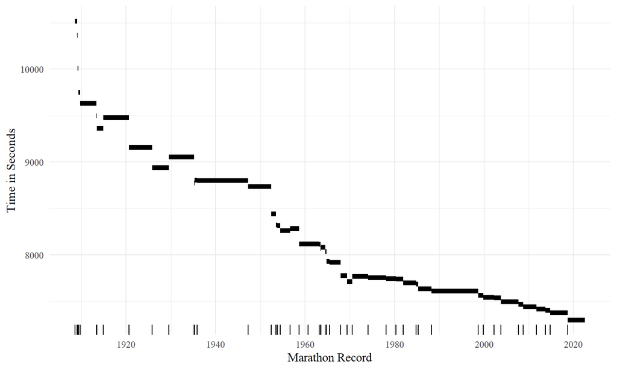

## Visualize B

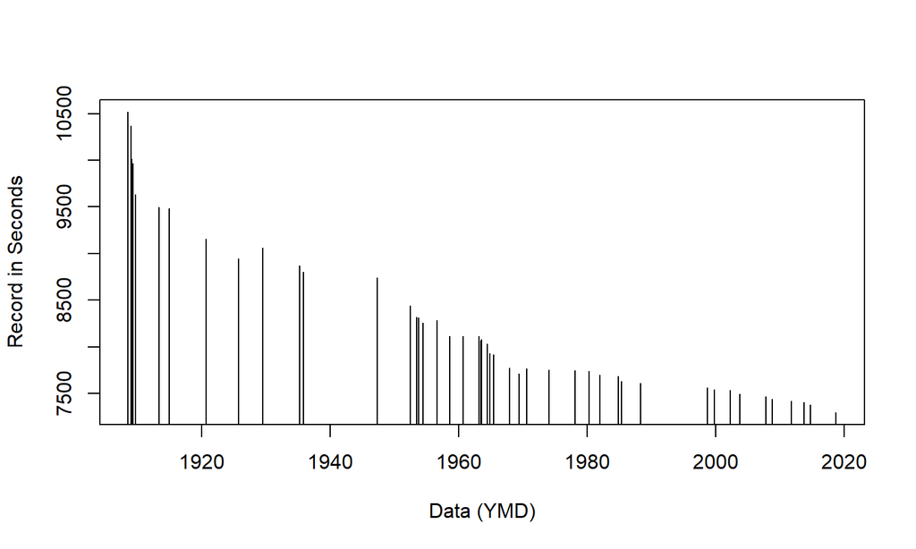

## Visualize C

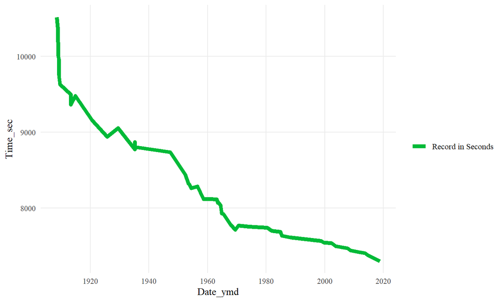

## SIMPLE MODEL

## POISSON PROCESS (NEED TO SHORTEN, OR PUT ON TWO SLIDES)

A model for a series of discrete events where the average time between events is known, but the exact timing of events is “random” meeting the following criteria:

- Events are independent of each other. The occurrence of one event does not affect the probability another event will occur.
- The average rate (events per time period) is constant.
- Two events cannot occur at the same time.

The time between events (known as the interarrival times) follow an exponential distribution defined as:

\[P(T>t) = e^{-\lambda t}\] Where T is the random variable of the time until the next event, t is a specific time for the next event, and \(\lambda\) is the rate: the average number of events per unit of time. Note the possible values of T are greater than 0 (positive only).

## Reasonableness of Exponential Interarrivals

The exponential distribution has certain attributes, for example:

\(E(T) = 1/\lambda\) \(SD(T) = 1/\lambda\)

The mean and standard deviation of the years between records:

```
## [1] 2.249427
```

```
## [1] 2.428191
```

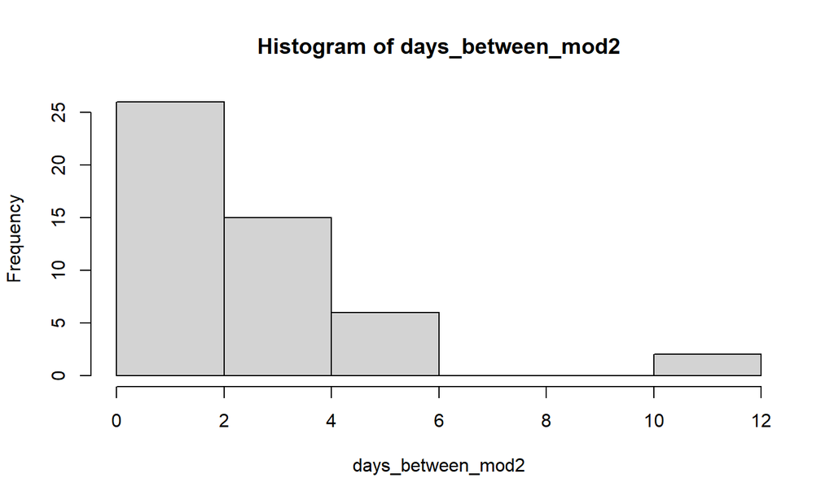

## MORE ON THE SIMPLE MODEL

We estimate (MLE) \(\lambda = 1/E(T)\)

```
##      rate
## 0.4445577
```

Model fit

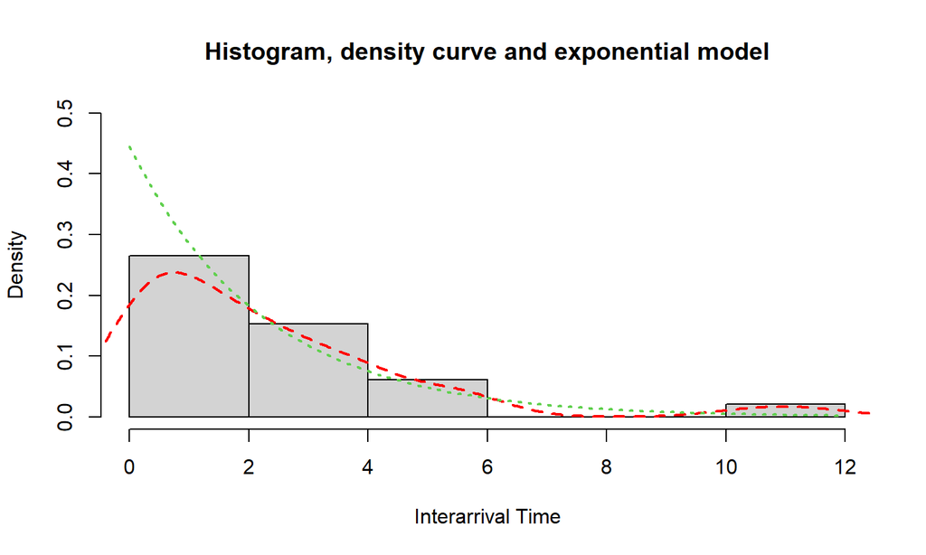

## Fit of simple model

```
##
##  Asymptotic one-sample Kolmogorov-Smirnov test
##
## data:  days_between_mod2
## D = 0.078053, p-value = 0.9264
## alternative hypothesis: two-sided
```

```
##
##  Cramer-von Mises test of goodness-of-fit
##  Braun's adjustment using 7 groups
##  Null hypothesis: exponential distribution
##  with parameter rate = 0.444557679401457
##  Parameters assumed to have been estimated from data
##
## data:  days_between_mod2
## omega2max = 0.60007, p-value = 0.1287
```

```
##
##  Anderson-Darling test of goodness-of-fit
##  Braun's adjustment using 7 groups
##  Null hypothesis: exponential distribution
##  with parameter rate = 0.444557679401457
##  Parameters assumed to have been estimated from data
##
## data:  days_between_mod2
## Anmax = 2.4992, p-value = 0.3085
```

## Fit of simple model B

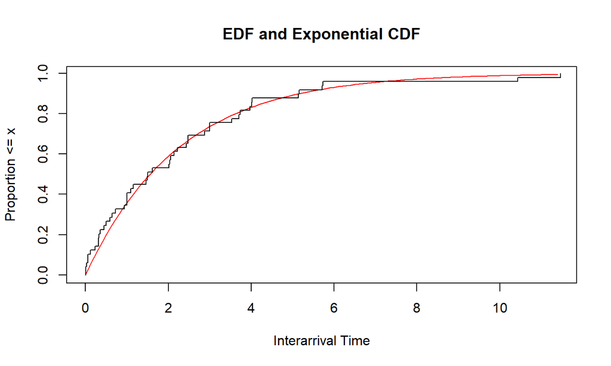

## Are records then random?

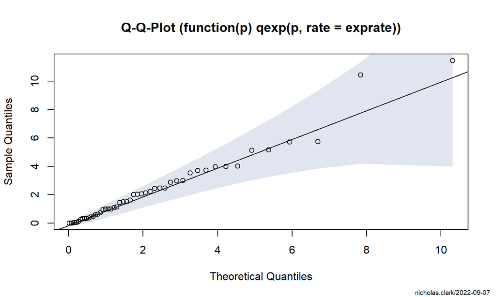

## A “Self-Exciting” Model

## Hawkes Processes

- Let \(H_t\) be the history of events up to time \(t\). The Hawkes (1971) model of the conditional intensity is:

\[\lambda(t|H_t) = \nu + \sum_{i:t_i<t} g(t - t_i)\] where \(\nu\) is the background rate of events and g is the “triggering function”.

- The “triggering” function can be further decomposed:

\[g = \mu g^*\] where \(g^*\) is a density function known as the “reproduction kernel” and \(\mu\) is known as the “reproduction” mean.

- A common choice for the “reproduction kernel” is the exponential density given by:

\[g^*(t) = \beta e^{-\beta t} \]

## Fitting the model

Parameter estimates for marathon data (exponential) Hawkes process, using MLE:

- baseline intensity 0.396
- reproduction mean 0.121
- exponential reproduction function rate 3.91

Note the baseline intensity is slightly lower than the constant model rate estimate of 0.445

The estimated reproduction function is then:

\[g(t) = \mu g^*(t) = \mu \beta e^{-\beta t} \] \[ = 0.12 * 3.91 e^{-3.91 t} \]

## Model implications

At the instant of the first event (world record), \(t = t_1\) so \(g(t - t_1 = 0)\) and the reproduction rate is:

\[g(0) = 0.12 * 3.91 e^{-3.91 0} = 0.12 * 3.91 = 0.471 \]

- The rate increases from the baseline rate of 0.396 by this amount at the moment of this occurrence
- The rate then decays back to baseline over time (unless a new event occurs).
- Each new event “excites” the rate to increase and then decay

## The Intensity Function over Time

Below is based on a simulation of the intensity function over a 100 year period. NOTE: HERE WOULD BE NICE TO SHOW FOR OUR DATA ALTHOUGH MIGHT NOT GIVE THE FULL PICTURE ANYWAY

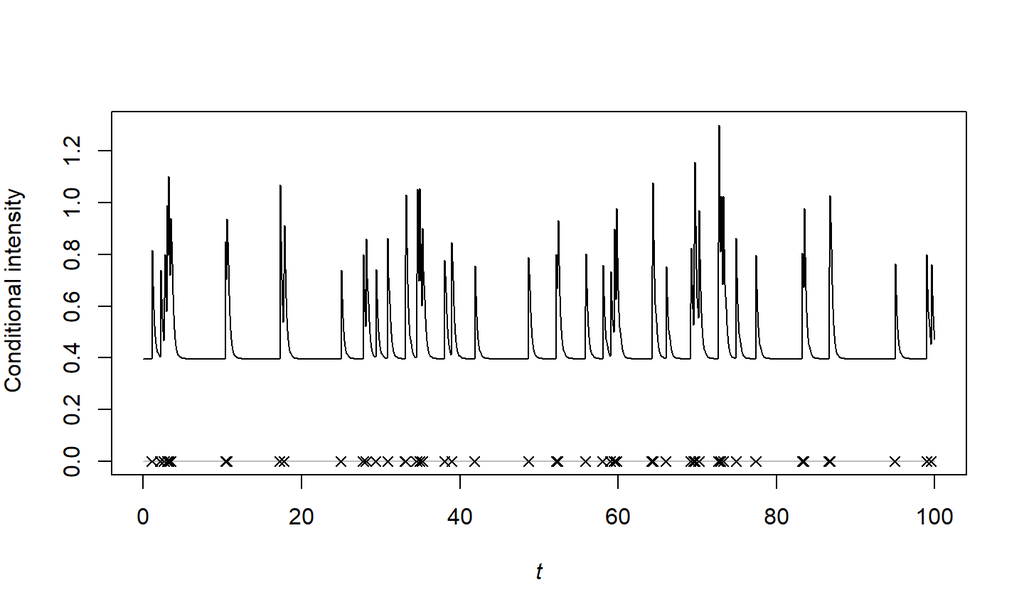

## Intensity compared to the constant rate model

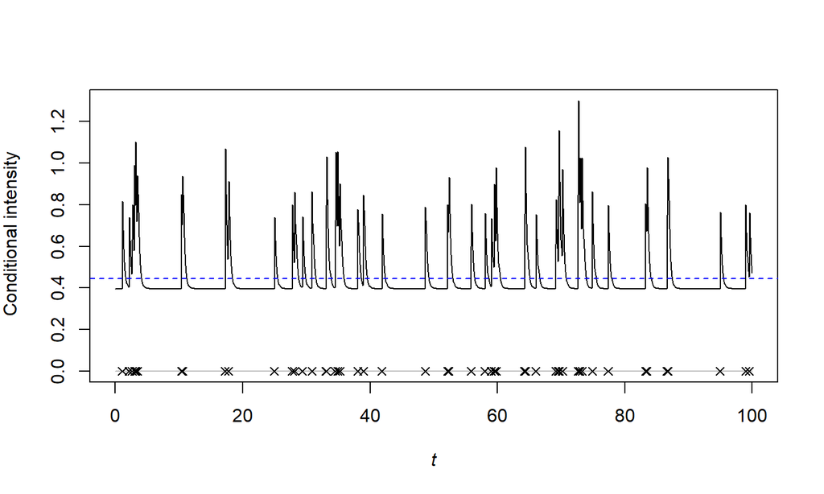

## Process as “Generations”

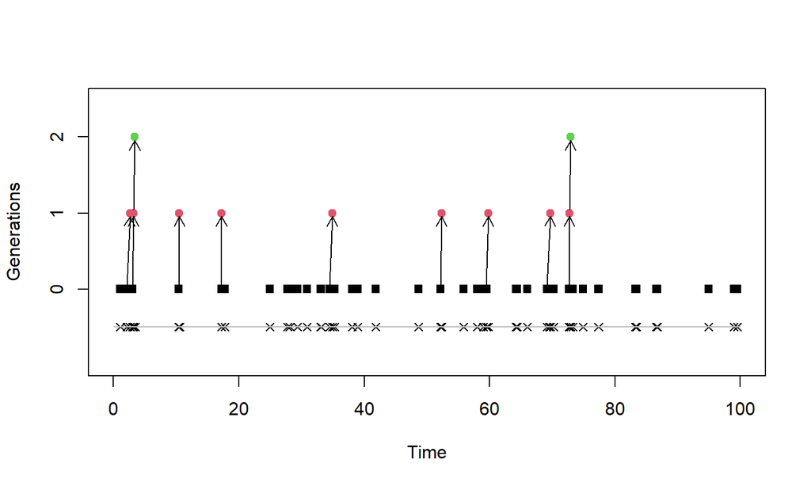

## The Compensator Function

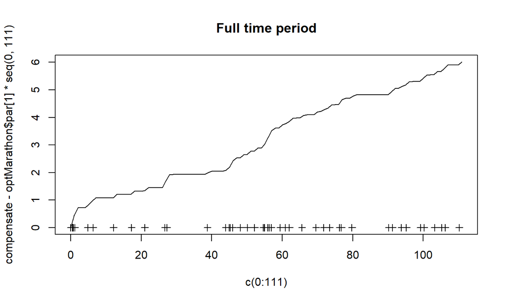

## References

Data source: Wikipedia (https://en.wikipedia.org/wiki/Marathon_world_record_progression) scraped August 12, 2022

Poisson process: https://towardsdatascience.com/the-poisson-distribution-and-poisson-process-explained-4e2cb17d459

Hawkes, Alan G. 1971. “Spectra of Some Self-Exciting and Mutually Exciting Point Processes.” Biometrika 58 (1): 83–90. https://doi.org/10.2307/2334319.

“Hawkesbow” package…